# Ex_StockPricePrediction_AMZN_tarea_g_cagua

## Content

- 1. Problem Definition
- 2. Getting Started - Load Libraries and Dataset
  - 2.1. Load Libraries
  - 2.2. Load Dataset
- 3. Exploratory Data Analysis
  - 3.1 Descriptive Statistics
  - 3.2. Data Visualisation
- 4. Data Preparation
  - 4.1 Data Cleaning
  - 4.2.Feature Selection
- 5.Evaluate Algorithms and Models
  - 5.1. Train/Test Split
  - 5.2. Evaluation Metrics
  - 5.3. Compare Models and Algorithms
    - 5.3.1 Machine Learning models-scikit-learn
    - 5.3.2 Time Series based Models-ARIMA and LSTM
- 6. Model Tuning and grid search
- 7. Finalise the model
  - 7.1. Result on the test dataset
  - 7.2. Actual vs Predicted Comparision

# 1. Problem Definition

In the supervised regression framework used for this case study, weekly return of the AMZN stock is the predicted variable. We need to understand what affects AMZN stock price and hence incorporate as much information into the model.

For this case study, other than the historical data of AMZN, the independent variables used are the following potentially correlated assets:

- Stocks: FACEBOOK (FB) and TESLA (TSLA)
- Currency: USD/JPY and GBP/USD
- Indices: S&P 500, Dow Jones and VIX

# 2. Getting Started- Loading the data and python packages

## 2.1. Loading the python packages

```python
from google.colab import drive
drive.mount('/content/drive', force_remount=True)
```

```python
# Load libraries
import numpy as np
import pandas as pd
import pandas_datareader.data as web
from matplotlib import pyplot
from pandas.plotting import scatter_matrix
import seaborn as sns
from sklearn.preprocessing import StandardScaler

from sklearn.model_selection import train_test_split
from sklearn.model_selection import KFold
from sklearn.model_selection import cross_val_score
from sklearn.model_selection import GridSearchCV

from sklearn.linear_model import LinearRegression
from sklearn.linear_model import Lasso
from sklearn.linear_model import ElasticNet
from sklearn.tree import DecisionTreeRegressor
from sklearn.neighbors import KNeighborsRegressor
from sklearn.svm import SVR
from sklearn.ensemble import RandomForestRegressor
from sklearn.ensemble import GradientBoostingRegressor
from sklearn.ensemble import ExtraTreesRegressor
from sklearn.ensemble import AdaBoostRegressor
from sklearn.neural_network import MLPRegressor

#Libraries for Deep Learning Models
from keras.models import Sequential
from keras.layers import Dense
#from keras.optimizers import SGD
from tensorflow.keras.optimizers import SGD
from keras.layers import LSTM
from keras.wrappers.scikit_learn import KerasRegressor

#Libraries for Statistical Models
import statsmodels.api as sm

#Libraries for Saving the Model
from pickle import dump
from pickle import load

# Time series Models
from statsmodels.tsa.arima_model import ARIMA
#from statsmodels.tsa.statespace.sarimax import SARIMAX

# Error Metrics
from sklearn.metrics import mean_squared_error

# Feature Selection
from sklearn.feature_selection import SelectKBest
from sklearn.feature_selection import chi2, f_regression


#Plotting
from pandas.plotting import scatter_matrix
from statsmodels.graphics.tsaplots import plot_acf
```

```python
from tensorflow.keras.utils import to_categorical
from tensorflow.keras.constraints import max_norm
```

```python
!pip install yfinance
```

```python
!pip install git+https://github.com/pydata/pandas-datareader.git
```

```
  Cloning https://github.com/pydata/pandas-datareader.git to /tmp/pip-req-build-s3_337rf
  Running command git clone -q https://github.com/pydata/pandas-datareader.git /tmp/pip-req-build-s3_337rf
```

```python
import pandas
from pandas_datareader import data as pdr
import yfinance as yfin
yfin.pdr_override()
#Diable the warnings
import warnings
warnings.filterwarnings('ignore')
```

## 2.2. Loading the Data

Next, we extract the data required for our analysis using pandas datareader.

```python
start = '2012-01-01'
end = '2021-12-31'
#data = pdr.get_data_yahoo(ticker, start, end)['Adj Close']
y ='AMZN'
stks_tickers = ['AMZN','TSLA','FB']
idx_tickers = ['SPY', '^DJI', '^VIX']
ccy_tickers = ['JPY=X', 'GBPUSD=X']
```

```python
AMZN_data = pdr.get_data_yahoo(y, start, end)['Adj Close']
```

```
[*********************100%***********************]  1 of 1 completed
```

```python
stks_data = pdr.get_data_yahoo(stks_tickers, start, end)
```

```
[*********************100%***********************]  3 of 3 completed
```

```python
idx_data = pdr.get_data_yahoo(idx_tickers, start, end)['Adj Close']
```

```
[*********************100%***********************]  3 of 3 completed
```

```python
ccy_data = pdr.get_data_yahoo(ccy_tickers, start, end)['Adj Close']

#stk_data = web.DataReader(stk_tickers, 'yahoo')
#ccy_data = web.DataReader(ccy_tickers, 'fred')
#idx_data = web.DataReader(idx_tickers, 'fred')
```

```
[*********************100%***********************]  2 of 2 completed
```

```python
stks_data.head()
```

| Date | Adj Close AMZN | Adj Close FB | Adj Close TSLA | Close AMZN | Close FB | Close TSLA | High AMZN | High FB | High TSLA | Low AMZN | Low FB | Low TSLA | Open AMZN | Open FB | Open TSLA | Volume AMZN | Volume FB | Volume TSLA |
| --- | --- | --- | --- | --- | --- | --- | --- | --- | --- | --- | --- | --- | --- | --- | --- | --- | --- | --- |
| 2012-01-03 | 179.029999 | NaN | 5.616 | 179.029999 | NaN | 5.616 | 179.479996 | NaN | 5.900 | 175.550003 | NaN | 5.530 | 175.889999 | NaN | 5.788 | 5110800 | NaN | 4640500 |
| 2012-01-04 | 177.509995 | NaN | 5.542 | 177.509995 | NaN | 5.542 | 180.500000 | NaN | 5.734 | 176.070007 | NaN | 5.500 | 179.210007 | NaN | 5.642 | 4205200 | NaN | 3150500 |
| 2012-01-05 | 177.610001 | NaN | 5.424 | 177.610001 | NaN | 5.424 | 178.250000 | NaN | 5.586 | 174.050003 | NaN | 5.370 | 175.940002 | NaN | 5.552 | 3809100 | NaN | 5027500 |
| 2012-01-06 | 182.610001 | NaN | 5.382 | 182.610001 | NaN | 5.382 | 184.649994 | NaN | 5.558 | 177.500000 | NaN | 5.282 | 178.070007 | NaN | 5.440 | 7008400 | NaN | 4931500 |
| 2012-01-09 | 178.559998 | NaN | 5.450 | 178.559998 | NaN | 5.450 | 184.369995 | NaN | 5.498 | 177.000000 | NaN | 5.224 | 182.759995 | NaN | 5.400 | 5056900 | NaN | 4485000 |

```python
ccy_data.head()
```

| Date | GBPUSD=X | JPY=X |
| --- | --- | --- |
| 2012-01-02 | 1.551205 | 77.019997 |
| 2012-01-03 | 1.552000 | 76.930000 |
| 2012-01-04 | 1.564407 | 76.722000 |
| 2012-01-05 | 1.560939 | 76.709999 |
| 2012-01-06 | 1.550171 | 77.151001 |

```python
idx_data.head()
```

| Date | SPY | ^DJI | ^VIX |
| --- | --- | --- | --- |
| 2012-01-03 | 104.950851 | 12397.379883 | 22.969999 |
| 2012-01-04 | 105.115433 | 12418.419922 | 22.219999 |
| 2012-01-05 | 105.395317 | 12415.700195 | 21.480000 |
| 2012-01-06 | 105.123680 | 12359.919922 | 20.629999 |
| 2012-01-09 | 105.378853 | 12392.690430 | 21.070000 |

Next, we need a series to predict. We choose to predict using weekly returns. We approximate this by using 5 business day period returns.

```python
return_period = 5
```

We now define our Y series and our X series

Y: AMZN **Future** Returns

X:

```
a. TSLA 5 Business Day Returns
b. FB 5 Business DayReturns
c. USD/JPY 5 Business DayReturns
d. GBP/USD 5 Business DayReturns
e. S&P 500 5 Business DayReturns
f. Dow Jones 5 Business DayReturns
g. AMZN 5 Business Day Returns
h. AMZN 15 Business Day Returns
i. AMZN 30 Business Day Returns
j. AMZN 60 Business Day Returns
```

We create the AMZN past returns when we use the Time series models.

```python
Y = np.log(AMZN_data /AMZN_data .shift(-return_period)).dropna()
Y.tail()
#log_rets=np.log(data/data.shift(1))
#log_rets.head()
```

```
Date
2021-12-16   -0.012929
2021-12-17    0.002049
2021-12-20   -0.021212
2021-12-21    0.007161
2021-12-22    0.014087
Name: Adj Close, dtype: float64
```

```python
Y.name = Y.name[-1]+'_pred'
Y=pd.DataFrame(Y)
Y.tail(5)
```

| Date | e_pred |
| --- | --- |
| 2021-12-16 | -0.012929 |
| 2021-12-17 | 0.002049 |
| 2021-12-20 | -0.021212 |
| 2021-12-21 | 0.007161 |
| 2021-12-22 | 0.014087 |

```python
Y= Y.rename(columns={'e_pred':'AMZN'})
Y=pd.DataFrame(Y)
Y.tail(5)
```

| Date | AMZN |
| --- | --- |
| 2021-12-16 | -0.012929 |
| 2021-12-17 | 0.002049 |
| 2021-12-20 | -0.021212 |
| 2021-12-21 | 0.007161 |
| 2021-12-22 | 0.014087 |

```python
X1 = np.log(stks_data.loc[:, ('Adj Close', ('TSLA', 'FB'))]/stks_data.loc[:, ('Adj Close', ('TSLA', 'FB'))].shift(return_period))
X1.columns = X1.columns.droplevel()
#X1.head
```

```python
#X1.columns = X1.columns.droplevel()
X2 = np.log(ccy_data).diff(return_period)
X3 = np.log(idx_data).diff(return_period)
```

```python
#y=np.log(GOOGL_data /GOOGL_data .shift(-return_period))
X4 = pd.concat([np.log(stks_data.loc[:, ('Adj Close', 'AMZN')]).diff(i) for i in [return_period, return_period*3, return_period*6, return_period*12]], axis=1).dropna()
X4.columns = ['AMZN_DT', 'AMZN_3DT', 'AMZN_6DT', 'AMZN_12DT']

X = pd.concat([X1, X2, X3, X4], axis=1).dropna()

X.tail(10)
```

| Date | TSLA | FB | GBPUSD=X | JPY=X | SPY | ^DJI | ^VIX | AMZN_DT | AMZN_3DT | AMZN_6DT | AMZN_12DT |
| --- | --- | --- | --- | --- | --- | --- | --- | --- | --- | --- | --- |
| 2021-12-16 | -0.079681 | 0.015285 | 0.004011 | 0.003968 | 0.000214 | 0.003990 | -0.047933 | -0.030902 | -0.058365 | -0.001946 | -0.000778 |
| 2021-12-17 | -0.086698 | 0.012177 | 0.007513 | 0.001893 | -0.019855 | -0.016978 | 0.143315 | -0.012825 | -0.030187 | -0.022291 | -0.004592 |
| 2021-12-20 | -0.071260 | -0.027398 | -0.002092 | 0.000150 | -0.021647 | -0.020368 | 0.118713 | -0.014784 | -0.063758 | -0.051730 | -0.024810 |
| 2021-12-21 | -0.021065 | 0.001377 | -0.000267 | 0.000748 | 0.002859 | -0.001449 | -0.041031 | 0.007808 | -0.028556 | -0.023384 | 0.000746 |
| 2021-12-22 | 0.033134 | -0.033361 | 0.002953 | 0.002204 | -0.002696 | -0.004842 | -0.034814 | -0.013231 | -0.006695 | -0.044452 | 0.031110 |
| 2021-12-23 | 0.140739 | 0.001015 | 0.006680 | -0.000131 | 0.012365 | 0.001473 | -0.135687 | 0.012929 | -0.004663 | -0.017580 | 0.035779 |
| 2021-12-27 | 0.159597 | 0.036447 | 0.013131 | 0.007154 | 0.037118 | 0.026148 | -0.198869 | -0.002049 | 0.001061 | -0.023045 | 0.032451 |
| 2021-12-28 | 0.190200 | 0.061866 | 0.017459 | 0.009893 | 0.046990 | 0.041112 | -0.265342 | 0.021212 | -0.004137 | -0.032267 | 0.038819 |
| 2021-12-29 | 0.146117 | 0.025816 | 0.012256 | 0.006810 | 0.030666 | 0.027674 | -0.214731 | -0.007161 | -0.040331 | -0.046666 | 0.059112 |
| 2021-12-30 | 0.059145 | 0.041232 | 0.010932 | 0.007221 | 0.017948 | 0.017857 | -0.072334 | -0.014087 | -0.043588 | -0.048555 | 0.046078 |

```python
dataset = Y.merge(X, left_index=True, right_index=True).dropna().iloc[::return_period, :]
#dataset = pd.concat([Y, X])
dataset.tail(10)
```

| Date | AMZN | TSLA | FB | GBPUSD=X | JPY=X | SPY | ^DJI | ^VIX | AMZN_DT | AMZN_3DT | AMZN_6DT | AMZN_12DT |
| --- | --- | --- | --- | --- | --- | --- | --- | --- | --- | --- | --- | --- |
| 2021-10-18 | 0.037353 | 0.094134 | 0.029936 | 0.010595 | 0.018130 | 0.028350 | 0.021865 | -0.203954 | 0.059913 | 0.011949 | -0.009043 | -0.059116 |
| 2021-10-25 | 0.000681 | 0.163692 | -0.020030 | 0.000083 | -0.005790 | 0.018522 | 0.013593 | -0.067855 | -0.037353 | 0.040124 | -0.040374 | -0.002172 |
| 2021-11-01 | -0.050214 | 0.164898 | 0.003917 | -0.005791 | 0.005020 | 0.009808 | 0.004820 | 0.073967 | -0.000681 | 0.021879 | -0.011274 | -0.008053 |
| 2021-11-08 | -0.016121 | -0.038503 | 0.025846 | -0.014130 | -0.006684 | 0.019140 | 0.014331 | 0.048181 | 0.050214 | 0.012181 | 0.024130 | 0.057516 |
| 2021-11-15 | -0.007555 | -0.137650 | 0.026059 | -0.005516 | 0.004449 | -0.003204 | -0.009508 | -0.043317 | 0.016121 | 0.065654 | 0.105778 | 0.102595 |
| 2021-11-22 | 0.018504 | 0.132417 | -0.019025 | 0.001302 | 0.001376 | 0.000300 | -0.013059 | 0.150592 | 0.007555 | 0.073890 | 0.095769 | 0.064435 |
| 2021-11-30 | -0.004614 | -0.010523 | -0.049750 | -0.006184 | -0.008627 | -0.026022 | -0.032399 | 0.349503 | -0.018504 | 0.005172 | 0.017352 | 0.008309 |
| 2021-12-07 | 0.040978 | -0.084740 | -0.005098 | -0.003814 | -0.003045 | 0.027539 | 0.035207 | -0.216819 | 0.004614 | -0.006335 | 0.059319 | 0.018945 |
| 2021-12-14 | -0.007808 | -0.092831 | 0.033298 | -0.003839 | 0.001048 | -0.010562 | -0.004918 | 0.000000 | -0.040978 | -0.054868 | 0.019022 | 0.007748 |
| 2021-12-21 | 0.007161 | -0.021065 | 0.001377 | -0.000267 | 0.000748 | 0.002859 | -0.001449 | -0.041031 | 0.007808 | -0.028556 | -0.023384 | 0.000746 |

```python
#Y = dataset.loc[:, Y.name]
X = dataset.loc[:, X.columns]
```

# 3. Exploratory Data Analysis

## 3.1. Descriptive Statistics

Lets have a look at the dataset we have

```python
pd.set_option('precision', 3)
dataset.describe()
```

|  | AMZN | TSLA | FB | GBPUSD=X | JPY=X | SPY | ^DJI | ^VIX | AMZN_DT | AMZN_3DT | AMZN_6DT | AMZN_12DT |
| --- | --- | --- | --- | --- | --- | --- | --- | --- | --- | --- | --- | --- |
| count | 482.000 | 482.000 | 482.000 | 4.820e+02 | 4.820e+02 | 482.000 | 482.000 | 4.820e+02 | 482.000 | 482.000 | 482.000 | 482.000 |
| mean | -0.006 | 0.011 | 0.004 | -4.485e-04 | 7.899e-04 | 0.003 | 0.002 | -5.898e-04 | 0.006 | 0.017 | 0.035 | 0.070 |
| std | 0.041 | 0.086 | 0.051 | 1.175e-02 | 1.183e-02 | 0.021 | 0.021 | 1.574e-01 | 0.041 | 0.067 | 0.091 | 0.122 |
| min | -0.182 | -0.563 | -0.270 | -8.822e-02 | -4.566e-02 | -0.134 | -0.169 | -5.562e-01 | -0.145 | -0.201 | -0.318 | -0.334 |
| 25% | -0.027 | -0.032 | -0.021 | -7.075e-03 | -5.591e-03 | -0.005 | -0.006 | -9.080e-02 | -0.015 | -0.018 | -0.020 | -0.014 |
| 50% | -0.008 | 0.008 | 0.006 | -8.691e-04 | 6.784e-04 | 0.005 | 0.003 | -1.364e-02 | 0.008 | 0.018 | 0.033 | 0.075 |
| 75% | 0.015 | 0.049 | 0.029 | 6.674e-03 | 7.180e-03 | 0.014 | 0.012 | 7.405e-02 | 0.027 | 0.054 | 0.090 | 0.153 |
| max | 0.145 | 0.448 | 0.328 | 5.096e-02 | 5.199e-02 | 0.107 | 0.112 | 9.601e-01 | 0.182 | 0.245 | 0.302 | 0.403 |

## 3.2. Data Visualization

Next, lets look at the distribution of the data over the entire period

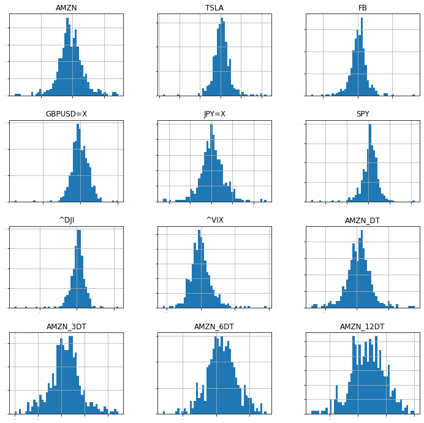

```python
dataset.hist(bins=50, sharex=False, sharey=False, xlabelsize=1, ylabelsize=1, figsize=(12,12))
pyplot.show()
```

The above histogram shows the distribution for each series individually. Next, lets look at the density distribution over the same x axis scale.

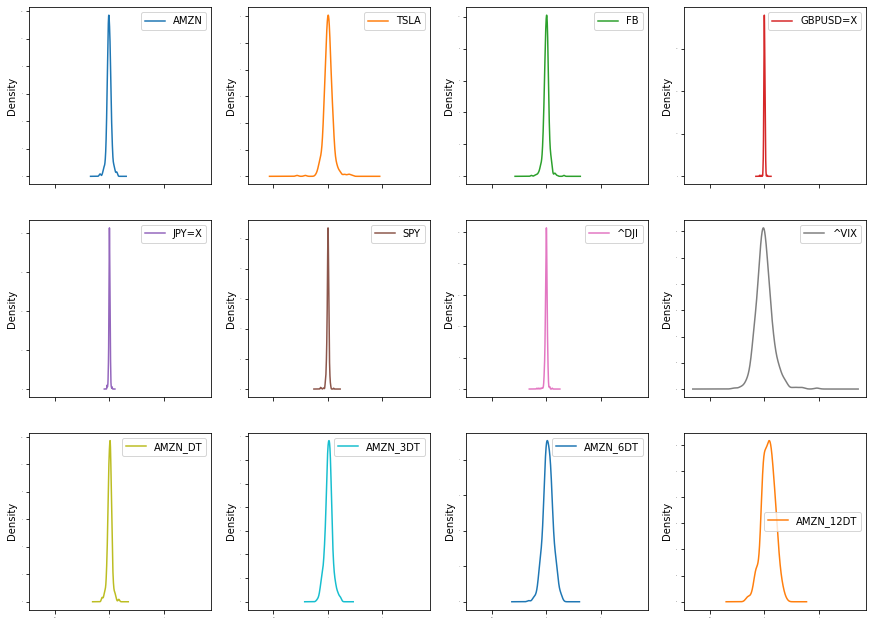

```python
dataset.plot(kind='density', subplots=True, layout=(4,4), sharex=True, legend=True, fontsize=1, figsize=(15,15))
pyplot.show()
```

We can see that the vix has a much larger variance compared to the other distributions.

In order to get a sense of the interdependence of the data we look at the scatter plot and the correlation matrix

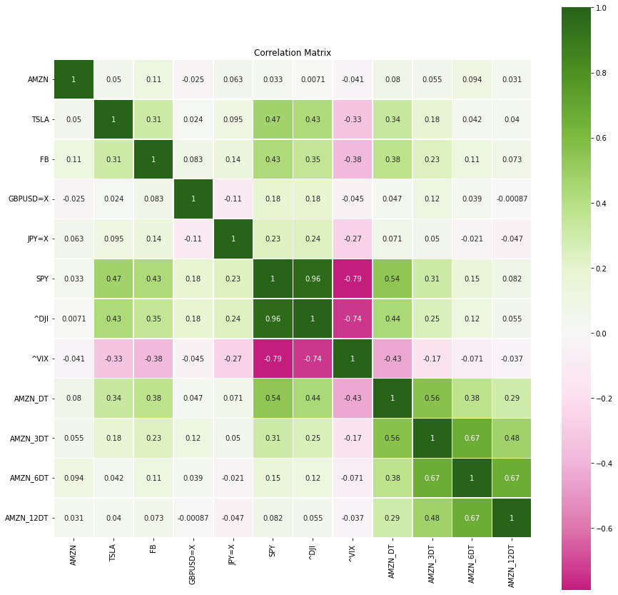

```python
correlation = dataset.corr()
pyplot.figure(figsize=(15,15))
pyplot.title('Correlation Matrix')
sns.heatmap(correlation, vmax=1, square=True,annot=True,cmap="PiYG", center=0, linewidths=.5)
```

Looking at the correlation plot above, we don't see some correlation of the predicted variable any of the other variables

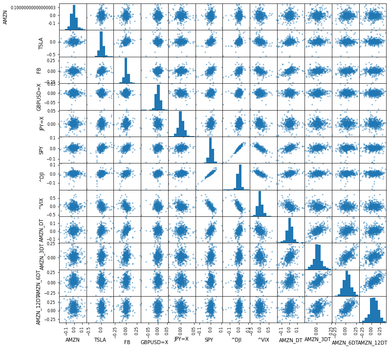

```python
pyplot.figure(figsize=(15,15))
scatter_matrix(dataset,figsize=(12,12))
pyplot.show()
```

Looking at the correlation plot above, we don't see some correlation of the predicted variable any of the other variables. Furthermore, there seems to be no correlation between the variable and any of its lags.

## 3.3. Time Series Analysis

Next, we look at the seasonal decomposition of our time series

```python
num_missing = (dataset[1:12] == 0).sum()
# report the results
print(num_missing)
```

```
AMZN         0
TSLA         0
FB           0
GBPUSD=X     0
JPY=X        0
SPY          0
^DJI         0
^VIX         0
AMZN_DT      0
AMZN_3DT     0
AMZN_6DT     0
AMZN_12DT    0
dtype: int64
```

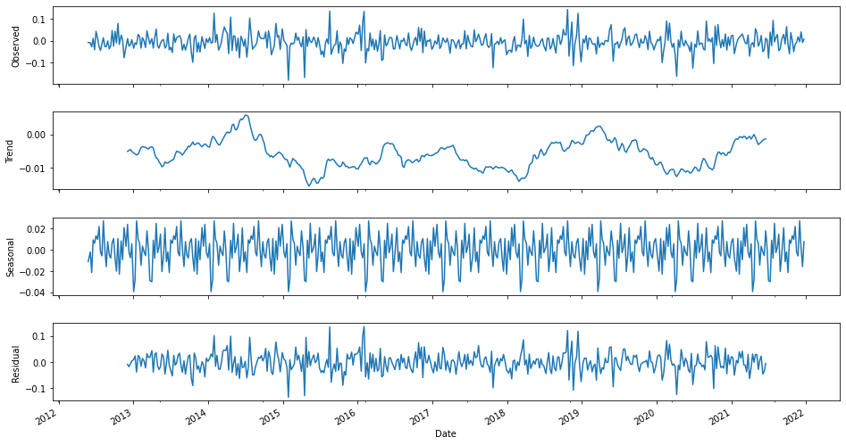

```python
res = sm.tsa.seasonal_decompose(dataset['AMZN'],freq=52)
fig = res.plot()
fig.set_figheight(8)
fig.set_figwidth(15)
pyplot.show()
```

There's not a defined trend in AMZN data series

## 4. Data Preparation

## 4.2. Feature Selection

We use sklearn's SelectKBest function to get a sense of feature importance.

```python
bestfeatures = SelectKBest(k=5, score_func=f_regression)
fit = bestfeatures.fit(X,dataset['AMZN'])
dfscores = pd.DataFrame(fit.scores_)
dfcolumns = pd.DataFrame(X.columns)
#concat:
featureScores = pd.concat([dfcolumns,dfscores],axis=1)
featureScores.columns = ['Specs','Score']
featureScores.nlargest(10,'Score').set_index('Specs')  #print 10 best features
```

| Specs | Score |
| --- | --- |
| FB | 6.227 |
| AMZN_6DT | 4.307 |
| AMZN_DT | 3.109 |
| JPY=X | 1.887 |
| AMZN_3DT | 1.478 |
| TSLA | 1.189 |
| ^VIX | 0.822 |
| SPY | 0.531 |
| AMZN_12DT | 0.473 |
| GBPUSD=X | 0.307 |

The most competitive features in terms of lags are AMZN_6DT and AMZN_DT.

# 5. Evaluate Algorithms and Models

## 5.1. Train Test Split and Evaluation Metrics

Next, we start by splitting our data in training and testing chunks. If we are going to use Time series models we have to split the data in continous series.

```python
validation_size = 0.15
Y=dataset['AMZN']
#In case the data is not dependent on the time series, then train and test split randomly
# seed = 7
# X_train, X_test, Y_train, Y_test = train_test_split(X, Y, test_size=validation_size, random_state=seed)

#In case the data is not dependent on the time series, then train and test split should be done based on sequential sample
#This can be done by selecting an arbitrary split point in the ordered list of observations and creating two new datasets.
train_size = int(len(X) * (1-validation_size))
X_train, X_test = X[0:train_size], X[train_size:len(X)]
Y_train, Y_test = Y[0:train_size], Y[train_size:len(X)]
```

## 5.2. Test Options and Evaluation Metrics

```python
num_folds = 10
seed = 7
# scikit is moving away from mean_squared_error.
# In order to avoid confusion, and to allow comparison with other models, we invert the final scores
scoring = 'neg_mean_squared_error'
```

## 5.3. Compare Models and Algorithms

### 5.3.1 Machine Learning models-from scikit-learn

##### Regression & Tree regression algorithms

```python
models = []
models.append(('LR', LinearRegression()))
models.append(('LASSO', Lasso()))
models.append(('EN', ElasticNet()))   #Combination between Lasso & Ridge
models.append(('KNN', KNeighborsRegressor()))
models.append(('CART', DecisionTreeRegressor()))
models.append(('SVR', SVR()))
```

##### Neural Network algorithms (Multilayer Perceptor)

```python
models.append(('MLP', MLPRegressor()))
```

##### Ensable Models (trees) (Boosting & Bagging)

```python
# Boosting methods
models.append(('ABR', AdaBoostRegressor()))
models.append(('GBR', GradientBoostingRegressor()))
# Bagging methods
models.append(('RFR', RandomForestRegressor()))
models.append(('ETR', ExtraTreesRegressor()))
```

Once we have selected all the models, we loop over each of them. First we run the K-fold analysis. Next we run the model on the entire training and testing dataset.

```python
from sklearn.model_selection import KFold
KFold
```

```
sklearn.model_selection._split.KFold
```

```python
names = []
kfold_results = []
test_results = []
train_results = []
for name, model in models:
    names.append(name)

    ## K Fold analysis:

    kfold = KFold(n_splits=num_folds, random_state=None)
    #converted mean square error to positive. The lower the beter
    cv_results = -1* cross_val_score(model, X_train, Y_train, cv=kfold, scoring=scoring)
    kfold_results.append(cv_results)


    # Full Training period
    res = model.fit(X_train, Y_train)
    train_result = mean_squared_error(res.predict(X_train), Y_train)
    train_results.append(train_result)

    # Test results
    test_result = mean_squared_error(res.predict(X_test), Y_test)
    test_results.append(test_result)

    msg = "%s: %f (%f) %f %f" % (name, cv_results.mean(), cv_results.std(), train_result, test_result)
    print(msg)
```

```
LR: 0.001792 (0.000673) 0.001665 0.001353
LASSO: 0.001714 (0.000716) 0.001704 0.001453
EN: 0.001714 (0.000716) 0.001704 0.001453
KNN: 0.002077 (0.000647) 0.001408 0.002071
CART: 0.004080 (0.001289) 0.000000 0.003249
SVR: 0.002510 (0.000911) 0.001972 0.002256
MLP: 0.001933 (0.000831) 0.001689 0.001428
ABR: 0.001951 (0.000647) 0.001098 0.001827
GBR: 0.002036 (0.000617) 0.000537 0.001462
RFR: 0.001869 (0.000642) 0.000262 0.001410
ETR: 0.001960 (0.000668) 0.000000 0.001457
```

#### CV results

We being by looking at the K Fold results

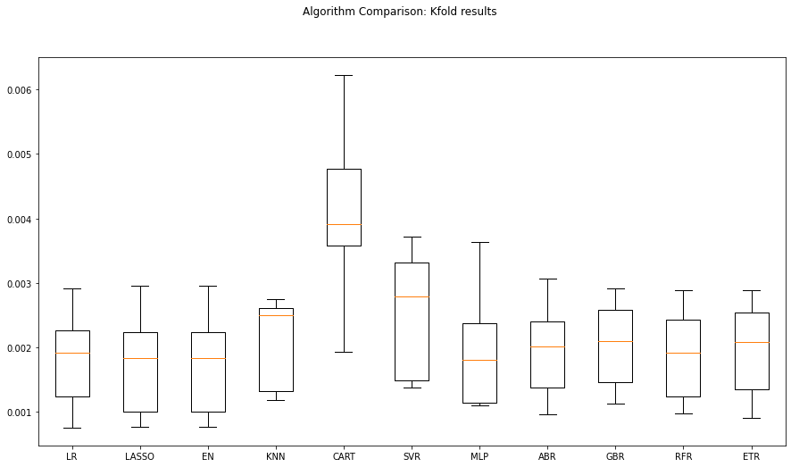

```python
fig = pyplot.figure()
fig.suptitle('Algorithm Comparison: Kfold results')
ax = fig.add_subplot(111)
pyplot.boxplot(kfold_results)
ax.set_xticklabels(names)
fig.set_size_inches(15,8)
pyplot.show()
```

We see linear regression, lasso, elastic net and neural networks fit the best. This happens because linear models fit data linearly according to each sector (that grows at the same rate).

#### Training and Test error

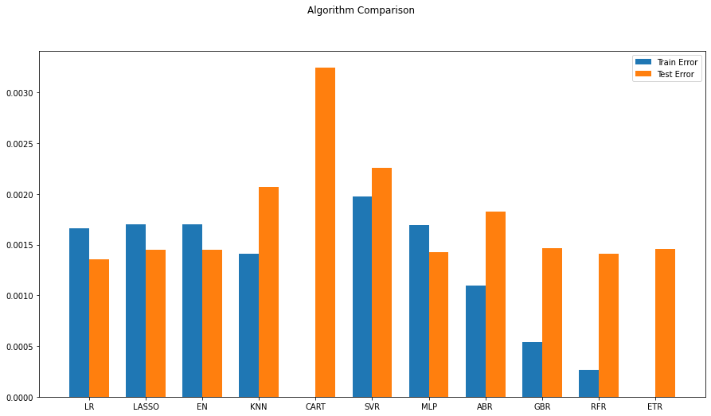

```python
# compare algorithms
fig = pyplot.figure()

ind = np.arange(len(names))  # the x locations for the groups
width = 0.35  # the width of the bars

fig.suptitle('Algorithm Comparison')
ax = fig.add_subplot(111)
pyplot.bar(ind - width/2, train_results,  width=width, label='Train Error')
pyplot.bar(ind + width/2, test_results, width=width, label='Test Error')
fig.set_size_inches(15,8)
pyplot.legend()
ax.set_xticks(ind)
ax.set_xticklabels(names)
pyplot.show()
```

### 5.3.1 Time Series based models-ARIMA and LSTM

Let us first prepare the dataset for ARIMA models, by having only the correlated varriables as exogenous variables.

### Time Series Model - ARIMA Model

```python
X_train_ARIMA=X_train.loc[:, ['TSLA', 'FB', 'SPY', '^DJI', '^VIX','JPY=X', 'GBPUSD=X']]
X_test_ARIMA=X_test.loc[:, ['TSLA', 'FB', 'SPY', '^DJI', '^VIX','JPY=X', 'GBPUSD=X']]
tr_len = len(X_train_ARIMA)
te_len = len(X_test_ARIMA)
to_len = len (X)
```

```python
modelARIMA=ARIMA(endog=Y_train,exog=X_train_ARIMA,order=[1,0,0])
model_fit = modelARIMA.fit()
```

```python
error_Training_ARIMA = mean_squared_error(Y_train, model_fit.fittedvalues)
predicted = model_fit.predict(start = tr_len -1 ,end = to_len -1, exog = X_test_ARIMA)[1:]
error_Test_ARIMA = mean_squared_error(Y_test,predicted)
error_Test_ARIMA
```

```
0.0014061708041725135
```

Having the error result of ARIMA model, we can conclude the model that fits the best (with the lowest error) is a linear regression.

### LSTM Model

```python
!pip uninstall tensorflow -y
!pip install tensorflow==2.2.0
```

[output not shown]

```python
seq_len = 2 #Length of the seq for the LSTM

Y_train_LSTM, Y_test_LSTM = np.array(Y_train)[seq_len-1:], np.array(Y_test)
X_train_LSTM = np.zeros((X_train.shape[0]+1-seq_len, seq_len, X_train.shape[1]))
X_test_LSTM = np.zeros((X_test.shape[0], seq_len, X.shape[1]))
for i in range(seq_len):
    X_train_LSTM[:, i, :] = np.array(X_train)[i:X_train.shape[0]+i+1-seq_len, :]
    X_test_LSTM[:, i, :] = np.array(X)[X_train.shape[0]+i-1:X.shape[0]+i+1-seq_len, :]
```

```python
# Lstm Network
def create_LSTMmodel(neurons=12, learn_rate = 0.01, momentum=0):
        # create model
    model = Sequential()
    model.add(LSTM(50, input_shape=(X_train_LSTM.shape[1], X_train_LSTM.shape[2])))
    #More number of cells can be added if needed
    model.add(Dense(1))
    optimizer = SGD(lr=learn_rate, momentum=momentum)
    model.compile(loss='mse', optimizer='adam')
    return model
LSTMModel = create_LSTMmodel(12, learn_rate = 0.01, momentum=0)
LSTMModel_fit = LSTMModel.fit(X_train_LSTM, Y_train_LSTM, validation_data=(X_test_LSTM, Y_test_LSTM),epochs=330, batch_size=72, verbose=0, shuffle=False)
```

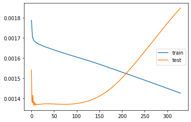

```python
#Visual plot to check if the error is reducing
pyplot.plot(LSTMModel_fit.history['loss'], label='train')
pyplot.plot(LSTMModel_fit.history['val_loss'], label='test')
pyplot.legend()
pyplot.show()
```

```python
error_Training_LSTM = mean_squared_error(Y_train_LSTM, LSTMModel.predict(X_train_LSTM))
predicted = LSTMModel.predict(X_test_LSTM)
error_Test_LSTM = mean_squared_error(Y_test,predicted)
```

#### Append to previous results

```python
test_results.append(error_Test_ARIMA)
test_results.append(error_Test_LSTM)

train_results.append(error_Training_ARIMA)
train_results.append(error_Training_LSTM)

names.append("ARIMA")
names.append("LSTM")
```

## Overall Comparison of all the algorithms ( including Time Series Algorithms)

[figure not shown]

```python
# compare algorithms
fig = pyplot.figure()

ind = np.arange(len(names))  # the x locations for the groups
width = 0.35  # the width of the bars

fig.suptitle('Comparing the performance of various algorthims on the Train and Test Dataset')
ax = fig.add_subplot(111)
pyplot.bar(ind - width/2, train_results,  width=width, label='Train Error')
pyplot.bar(ind + width/2, test_results, width=width, label='Test Error')
fig.set_size_inches(15,8)
pyplot.legend()
ax.set_xticks(ind)
ax.set_xticklabels(names)
pyplot.ylabel('Mean Square Error')
pyplot.show()
```

Looking at the chart above, we find time series based ARIMA model performs almost equal compared to the linear supervised-regression models such as Lasso Regres‐ sion (LASSO) and Elastic Net (EN).

# 6. Model Tuning and Grid Search

As shown in the chart above the ARIMA model is one of the best mode, so we perform the model tuning of the ARIMA model. The default order of ARIMA model is [1,0,0]. We perform a grid search with different combination p,d and q in the ARIMA model's order.

```python
#Grid Search for ARIMA Model
#Change p,d and q and check for the best result

# evaluate an ARIMA model for a given order (p,d,q)
#Assuming that the train and Test Data is already defined before
def evaluate_arima_model(arima_order):
    #predicted = list()
    modelARIMA=ARIMA(endog=Y_train,exog=X_train_ARIMA,order=arima_order)
    model_fit = modelARIMA.fit()
    error = mean_squared_error(Y_train, model_fit.fittedvalues)
    return error

# evaluate combinations of p, d and q values for an ARIMA model
def evaluate_models(p_values, d_values, q_values):
    best_score, best_cfg = float("inf"), None
    for p in p_values:
        for d in d_values:
            for q in q_values:
                order = (p,d,q)
                try:
                    mse = evaluate_arima_model(order)
                    if mse < best_score:
                        best_score, best_cfg = mse, order
                    print('ARIMA%s MSE=%.7f' % (order,mse))
                except:
                    continue
    print('Best ARIMA%s MSE=%.7f' % (best_cfg, best_score))

# evaluate parameters
p_values = [0, 1, 2]
d_values = range(0, 2)
q_values = range(0, 2)
warnings.filterwarnings("ignore")
evaluate_models(p_values, d_values, q_values)
```

```
ARIMA(0, 0, 0) MSE=0.0016779
ARIMA(0, 0, 1) MSE=0.0016763
ARIMA(1, 0, 0) MSE=0.0016764
ARIMA(1, 0, 1) MSE=0.0016514
ARIMA(2, 0, 0) MSE=0.0016760
ARIMA(2, 0, 1) MSE=0.0016587
Best ARIMA(1, 0, 1) MSE=0.0016514
```

# 7. Finalise the Model

## 7.1. Results on the Test Dataset

```python
## LSTM
error_Test_LSTM = mean_squared_error(Y_test,predicted)
error_Test_LSTM
```

```
0.0017407042785284443
```

```python
# prepare model
modelARIMA_tuned=ARIMA(endog=Y_train,exog=X_train_ARIMA,order=[1,0,1])
model_fit_tuned = modelARIMA_tuned.fit()
```

```python
# estimate accuracy on validation set
predicted_tuned = model_fit.predict(start = tr_len -1 ,end = to_len -1, exog = X_test_ARIMA)[1:]
print(mean_squared_error(Y_test,predicted_tuned))
```

```
0.0014061708041725135
```

## Comparision Actual vs Predicted

[figure not shown]

```python
import matplotlib.pyplot as plt
#comparison of actual vs. predicted
predicted_tuned.index = Y_test.index
pyplot.plot(np.exp(Y_test).cumprod(), 'r') ##cumprod para entregar precios
pyplot.plot(np.exp(predicted_tuned).cumprod(), 'b')
pyplot.rcParams["figure.figsize"] = (8,5)
pyplot.ylabel('AAPL Prices')
plt.legend(['Actual', 'Predicted'])
pyplot.show()
```

### Summary

We can conclude that simple models - linear regression, regularized regression (i.e. Lasso and elastic net) - along with the time series model such as ARIMA are promising modelling approaches for asset price prediction problem if the data shows high levels of linearity.